# Business_Style_Telco_Churn_Report

## Executive Summary

This report presents the results of a churn prediction analysis for a telecommunications provider. Using a machine learning model trained on customer data, we identify individuals most at risk of leaving. By targeting the top 30% of high-risk customers, the business can potentially retain nearly 90% of all churners. Key churn drivers include monthly charges, contract type, and access to support services.

## Business Objective

The goal of this project is to help reduce customer churn by predicting which customers are most likely to leave, and by identifying key factors influencing those decisions. The insights are intended to support more targeted and cost-effective customer retention strategies.

## Dataset Summary

- Total Customers: 7,043
- Target Variable: `Churn` (Yes/No)
- Features include: Tenure, MonthlyCharges, TotalCharges, Contract Type, Internet Service, Tech Support, Online Security, ect.
- Churn Rate: ~27%

## Key Insights

- **Month-to-month contracts** are a major driver of churn as they strongly correlate with SHAP values pushing churn liklihood upwards. Comparatively customers with longer contracts are typically more likely to stay.
- Higher **monthly charges** associated with churners whilst higher **total charges** reduce churn risk (typically associated with longer tenure) - suggests pricing tolerance threshold for monthly charges.
- Customers without **Tech support or Online security** are more likely to churn. E.g. Customers without online security possed 1,461 churners compared to 295 who had the service - a ~5x difference
- **Fiber optic** customers churn more than **DSL** - possibly due to higher prices or unmet speed/reliability expectations.

## Cumulative Gains & Lift Analysis

- Targeting top **30%** of customers by churn risk captures **89.6%** of actual churners.
- To capture **95%**, you need to target the top **34%**.
- **Lift in the top 10%** is **~3.5×** — targeting customers in this percentile is ~3.5x more effective than random selection.

## Strategic Recommendations

- Incentivise month-to-month contract users to switch to longer plans utilising targeted offers or fixed rate contracts.
- Promote bundle services: bundle tech support and online security for high risk customers.
- Monitor customers with **high monthly charges and low tenure** - particularly those identified as being high risk.
- Fiber optic investigation: investigate churn causes amongst users and adjust expectations/offers accordingly.
- Prioritise top ~30% for marketing and retention efforts for best ROI.

## Model Overview

A CatBoost classifier was used for churn prediction, with Optuna-based optimisation focusing on F1 score due to class imbalance. The model was evaluated on a hold-out test using standard evaluation metrics.

- Final model performance on test data:
  - **Accuracy**: 88%
  - **Recall (Churn class)**: 96%
  - **AUC**: 0.96
  - **Cohen Kappa**: 0.73

The table bellow provides the full model evaluation. Overall, the model is highly effective at distinguishing churners and non-churners and ranking them by risk probability.

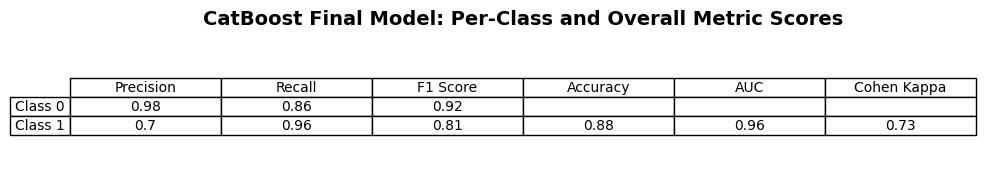

## Considerations

- Model effectiveness relies upon timely up to date data. Retraining necessary for optimal results - likely annually or bi-annually.
- Despite model effectiveness always a chance for non-churning customers to be pooled with churner retention efforts.
- Dataset may reflect biases based on regional, economic and demographic differences. Suggest future data incorporates these factors.

## Appendix

Supporting graphics can be found here such as:

- SHAP summary plot: Highlights most contributing features.
- Feature importance chart: Ranks features on relative importance.
- Cumulative gains chart: Shows percentage of churners captured by percentile.
- Lift chart: measures model effectivenss over random targeting.
- Probability distribution plot: Shows predicted liklihoods of customers churning and whether they did/didn't.

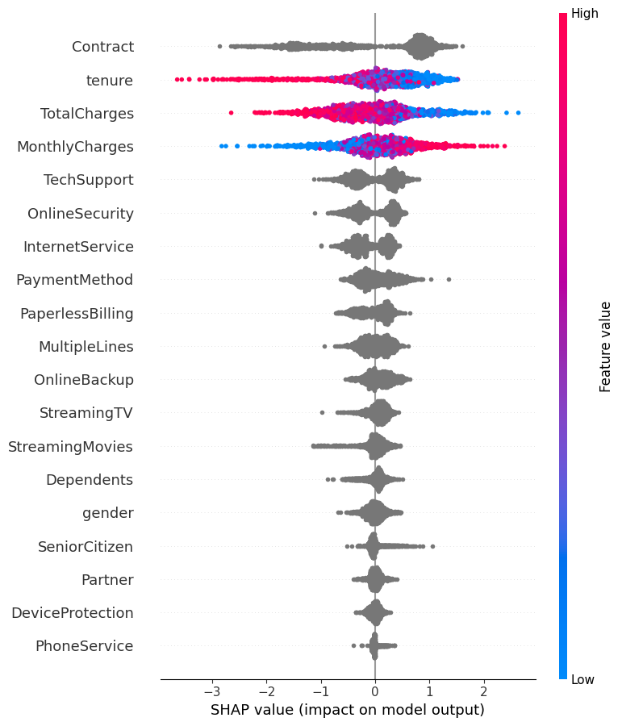

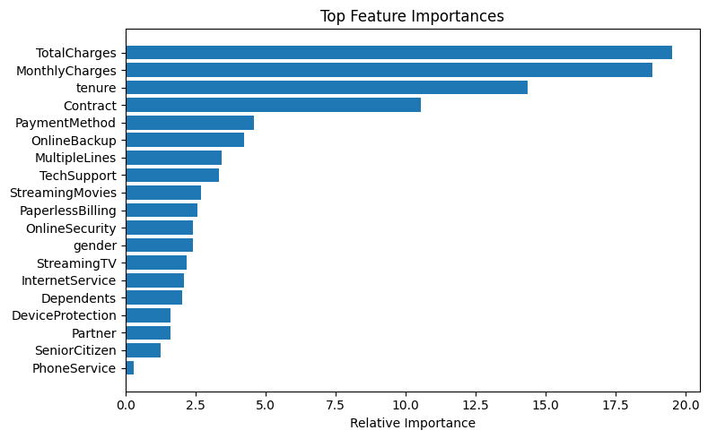

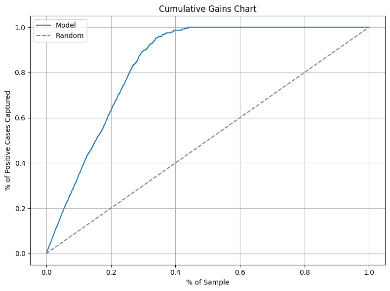

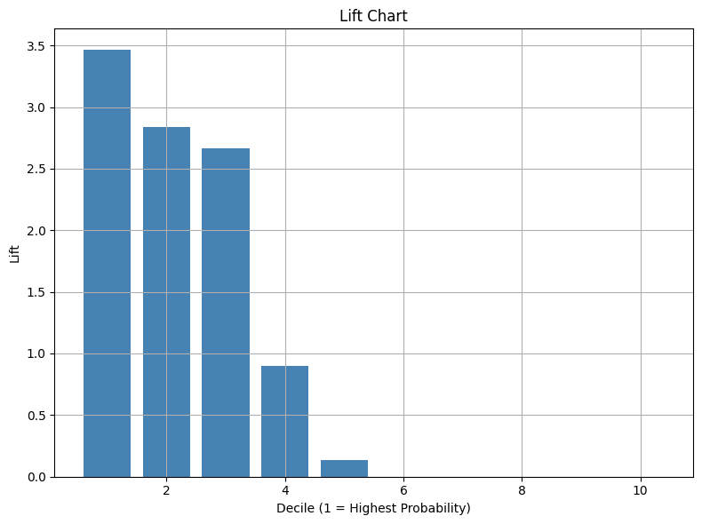

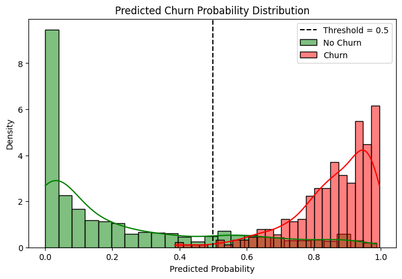